# POLI 110

March 29, 2019

## Correlation to Causation

## Plan for Today:

### **(1) Solutions for Bias**

- design-based
  - difference in difference
  - natural experiments

## Design-Based Solutions

## Design

### **Types of designs:**

Designs using conditioning

- Compare same case over time
- Compare cases known to be similar at same time
- "Differences in Differences"

Designs using random exposure to \(X\)

- experiments
- "natural experiments"

## Design: Difference in Difference

**What is it?**

- Compare changes in "treated" cases to changes in "untreated" cases before and after the "treatment"

**How does it work?**

- Hold constant **unchanging** attributes of cases (compare same case before and after "treatment")
- Hold constant variables that **change together** over time in "treated" and "untreated" cases

**Assumption**:

- "Untreated" case has the trend the "Treated" case **would have had** except for the "treatment"
- no variables that affect \(Y\) and change over time differently in "treated" and "untreated" cases

## Difference in Difference: Example

**Mueller and Schwarz 2018**

Does social-media hate speech lead to real-world violence?

- Anti-Refugee content on Facebook and Anti-Refugee violence in Germany
- Does anti-refugee hate speech on **AfD** (far right party) Facebook page cause increases in anti-refugee violence?

## Difference in Difference: Example

**Mueller and Schwarz 2018**

**Data**

- anti-refugee violence in Germany by week (and by town)
- anti-refugee comments on **AfD** Facebook page (by week)
- **AfD** Facebook followers per capita (by town)
- **Nutella** Facebook followers per capita (by town)

## Difference in Difference: Example

**Mueller and Schwarz 2018**

Research options:

- "Same case over time": compare Germany-wide anti-refugee violence following Facebook hate speech

## Difference in Difference: Example

[figure not shown]

## Difference in Difference: Example

**Mueller and Schwarz 2018**

Research options:

- "Same case over time": compare Germany-wide anti-refugee violence following Facebook hate speech
  - Could be that other events (terror attacks, political disputes over refugees) cause both hate speech AND violence (confounding)
- "Similar cases at same time": compare anti-refugee violence over same period in communities with many **AfD** facebook followers versus few **AfD** followers

## Difference in Difference: Example

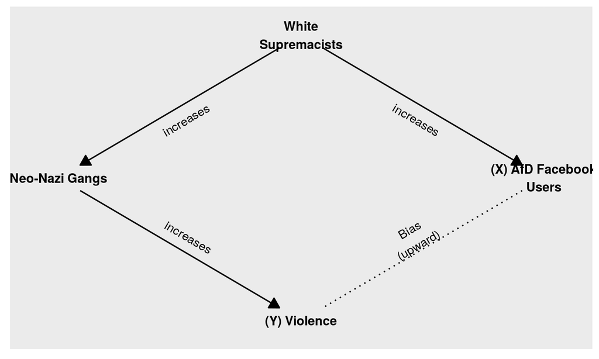

## Difference in Difference: Example

**Mueller and Schwarz 2018**

Research options:

- "Same case over time": compare Germany-wide anti-refugee violence following Facebook hate speech
  - Could be that other events (terror attacks, political disputes over refugees) cause both hate speech AND violence (confounding variables over time)
- "Similar cases at same time": compare anti-refugee violence over same period in communities with many **AfD** facebook followers versus few **AfD** followers
  - Could be that people who follow **AfD** on Facebook more likely to commit violence any way. ("similar" cases still fundamentally different)

## Difference in Difference: Example

**Difference-in-Difference**:

Consider 2 types of towns: \(Town_T\) and \(Town_C\) at two times: \(Before\) and \(After\) **AfD** anti-Refugee comment

- \(Town_T\) has many **AfD** Facebook followers
- \(Town_C\) has few **AfD** Facebook followers

We measure \(Hate \ Crimes\) (\(Y\)) in both towns

## Difference in Difference: Example

**Difference-in-Difference**:

- \(FirstDiff = Hate \ Crime_{After} - Hate \ Crime_{Before}\) gives us change in murders in a \(Town\)…
  - holding **unchanging attributes of town** (presence of refugees, Neo-Nazis, etc.) constant (*same case over time*)
- \(SecondDiff = FirstDiff_{T} - FirstDiff_{C}\) gives us change in murders in \(Treated\) towns over time, compared to \(Control\)
  - holding **shared trends of both towns** (exposure to political events/news) constant (*similar cases at same points in time*)

## Difference in Difference: Example

**Mueller and Schwarz 2018**

Using difference-in-difference, find that:

1. In weeks with more hateful Facebook Posts (compared to weeks with less)…
2. Towns with **more** AfD or Nutella Facebook followers (compared to towns with less)…
3. see **more** anti-refugee violence

Anti-Refugee violence is rare, but "high" Facebook usage areas have 60% more when there a more anti-refugee posts

## Difference in Difference: Example

**Assumptions for causality**:

- No variables that affect anti-refugee violence that change **differently** over time in places with more Facebook users as in places with fewer

## Difference in Difference: Example

A problem:

What if events involving refugees (crime, influx of refugees, etc.) makes white supremacists more angry but has no effect on non-white supremacists?

- something changing over time (events involving refugees causes ANGER) that
  - increases anti-refugee Facebook content
  - separately, increases anti-refugee violence
  - does so **more** in places that have more **AfD** Facebook followers.

Something that affect violence but changes differently over time in "treated" and "untreated" communities

Confounding!

## Design: Natural Experiments

**What is it?**:

- Comparison of cases where value of \(X\) is determined random (or approximately random)

**How does it work?**

- Because \(X\) is random, it is unrelated to any \(W\) that causes \(Y\); confounding not possible
- Cases with different values of \(X\) are, on average, the same on all other attributes

**Assumption for causality**

- \(X\) is actually random

## Design: Natural Experiments

1. "Standard" Natural Experiments: \(X\) is decided at random
   - Example: Does having more money make you more conservative on taxation?
   - Solution: compare lottery winners and losers
2. Arbitrary Cut-offs:
   - Does electing secular political parties reduced religious violence?
   - Solution: Compare places where secular parties *barely won* to where they *barely lost*
3. Something random (\(Z\)) that affects \(X\) for some cases

## Natural Experiments: Example

Is there anything **random** that affects exposure to Facebook hate speech?

**Internet outages**:

- where and when they occur is likely random, unrelated to
  - community's baseline white supremacism
  - major events in Germany involving refugees
- but internet outages **reduce** exposure to Facebook

## Natural Experiments: Example

When compared to places without internet outages, places with internet outages

1. In weeks with more hateful Facebook Posts (compared to weeks with less)…
2. Towns with **more** AfD or Nutella Facebook followers (compared to towns with less)…
3. see **no differene** in anti-refugee violence

Random loss of internet leads to no effect of Facebook posts on anti-refugee violence

|  | How Bias Solved | Which Bias Removed | Assumes | Internal Validity | External Validity |
| --- | --- | --- | --- | --- | --- |
| Adjustment | Hold constant | All **measured** confounding variables | Condition all confounders | Lowest | Highest |
| Similar Cases | Hold constant | Cases' **shared** confounding variables | **No** diff. b/t cases | Middle | Middle |
| Same Case | Hold constant | Case's **unchanging** confounding variables | **No** confounding trends | Middle | Middle |
| Diff in Diff | Hold constant | Case's **unchanging** variables Cases' **shared** trends | Cases have parallel trends | Higher | Lower |
| Natural Experiment | Break \(W \rightarrow X\) link | **All** confounding variables | \(X\) as-if random | Highest | Lowest |